# Programming Language Preference

2020-09-13

# Welcome to the world of data science

Throughout the world of data science, there are many languages and tools that can be used to complete a given task. And I’m writing this blog using R.

Thanks to LBS, I have access to Datacamp projects. So in this project, we are going to find out what tools and languages professionals use in their day-to-day work. Our data comes from the Kaggle Data Science Survey which includes responses from over 10,000 people that write code to analyze data in their daily work.

```r
# Load necessary packages
library(plyr)  #Data Manipulation
library(tidyverse) # Tidy data and other packages
library(ggplot2) #Data Visualisation
library(ggthemes)
library(plotly)
library(RColorBrewer)
library(scales)
library(cowplot)
library(wordcloud2)
library(splitstackshape)
library(reshape2)
library(wordcloud)
library(viridis)
library(plotrix)
library(knitr)
library(kableExtra)
library(stringr)
library(here)
```

```r
# Load the data
survey <- vroom::vroom(here::here("data","Kaggle_language_multipleChoiceResponses.csv"),
                                col_names=TRUE)

#kbl(head(survey,3)) %>%
  #kable_styling(full_width = F) %>%
  #kable_styling(bootstrap_options = c("striped", "hover", "condensed", "responsive"))

# We need unique identifiers for each observation
survey_withid<- tibble::rowid_to_column(survey, "Respondent")
```

```r
# Subset only what we need
responses <- survey_withid %>%
              select(Respondent, WorkToolsSelect,
                      LanguageRecommendationSelect,EmployerIndustry, WorkAlgorithmsSelect)
# Print the first 6 rows
#kbl(head(responses,6)) %>%
  #kable_styling(full_width = F) %>%
  #kable_styling(bootstrap_options = c("striped", "hover", "condensed", "responsive"))
```

# Using multiple tools

Now that we have loaded in the survey results, we want to focus on the tools and languages that the survey respondents use at work.

To learn how many people use each tool, we need to separate out all of the tools used by each individual. There are several ways to complete this task, but we will use str_split() from stringr to separate the tools at each comma. Since that will create a list inside of the data frame, we can use the tidyr function unnest() to separate each list item into a new row.

```r
# Print the first respondent's tools and languages
responses  %>% filter(Respondent=="2")  %>%  select (WorkToolsSelect)
```

```
## # A tibble: 1 x 1
##   WorkToolsSelect
##   <chr>
## 1 <NA>
```

```r
# Add a new column, and unnest the new column
tools <- responses  %>%
    mutate(work_tools = str_split(WorkToolsSelect,","))  %>%
    unnest(work_tools)

# View the first 6 rows of tools
# head(tools,6)
```

# Counting users of each tool

Now that we’ve split apart all of the tools used by each respondent, we can figure out which tools are the most popular.

```r
# Group the data by work_tools, summarise the counts, and arrange in descending order
tool_count <- tools  %>%
    group_by(work_tools)  %>%
    summarise(count=n())  %>%
    arrange(desc(count))

# Print the first 6 results
head(tool_count,6)
```

```
## # A tibble: 6 x 2
##   work_tools        count
##   <chr>             <int>
## 1 <NA>               8761
## 2 Python             6073
## 3 R                  4708
## 4 SQL                4261
## 5 Jupyter notebooks  3206
## 6 TensorFlow         2256
```

# Plotting the most popular tools

Let’s see how the most popular tools stack up against the rest.

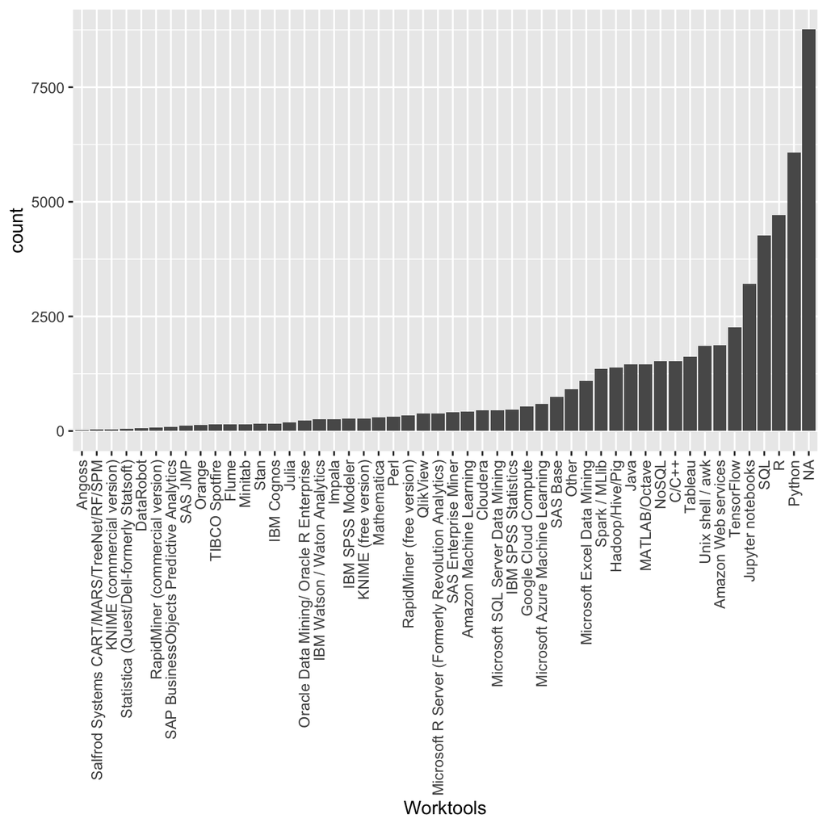

```r
# Create a bar chart of the work_tools column, most counts on the far right
ggplot(tool_count,aes(x=fct_reorder(work_tools,count),y=count)) +
    geom_bar(stat="identity") +
    labs(x="Worktools")+
    theme(axis.text.x  = element_text(angle = 90,
                                     vjust = 0.5,
                                     hjust = 1))
```

# The R vs Python debate Within the field of data science, there is a lot of debate among professionals about whether R or Python should reign supreme. You can see from our last figure that R and Python are the two most commonly used languages, but it’s possible that many respondents use both R and Python. Let’s take a look at how many people use R, Python, and both tools.

```r
# Create a new column called language preference
debate_tools <- responses  %>%
   mutate(language_preference = case_when(
       str_detect(WorkToolsSelect,"R")&str_detect(WorkToolsSelect,"Python",negate=TRUE) ~ "R",
       str_detect(WorkToolsSelect,"Python")&str_detect(WorkToolsSelect,"R",negate=TRUE) ~ "Python",
        str_detect(WorkToolsSelect,"R")&str_detect(WorkToolsSelect,"Python") ~"both",
       TRUE ~"neither"
   ))
# # Returns TRUE if the pattern do NOT match
#str_detect(fruit, "^p", negate = TRUE)
```

[output not shown]

```r
# Print the first 6 rows
head(debate_tools,6)
```

```
## # A tibble: 6 x 6
##   Respondent WorkToolsSelect LanguageRecomme… EmployerIndustry
##        <int> <chr>           <chr>            <chr>
## 1          1 Amazon Web ser… F#               Internet-based
## 2          2 <NA>            Python           <NA>
## 3          3 <NA>            R                <NA>
## 4          4 Amazon Machine… Python           Mix of fields
## 5          5 C/C++,Jupyter … Python           Technology
## 6          6 Jupyter notebo… Python           Academic
## # … with 2 more variables: WorkAlgorithmsSelect <chr>,
## #   language_preference <chr>
```

# Plotting R vs Python users

Now we just need to take a closer look at how many respondents use R, Python, and both!

```r
# Group by language preference, calculate number of responses, and remove "neither"
debate_plot <- debate_tools  %>%
   group_by(language_preference)  %>%
   summarise(count=n())  %>%
    filter(language_preference != "neither")
debate_plot
```

```
## # A tibble: 3 x 2
##   language_preference count
##   <chr>               <int>
## 1 both                 3660
## 2 Python               2413
## 3 R                    1220
```

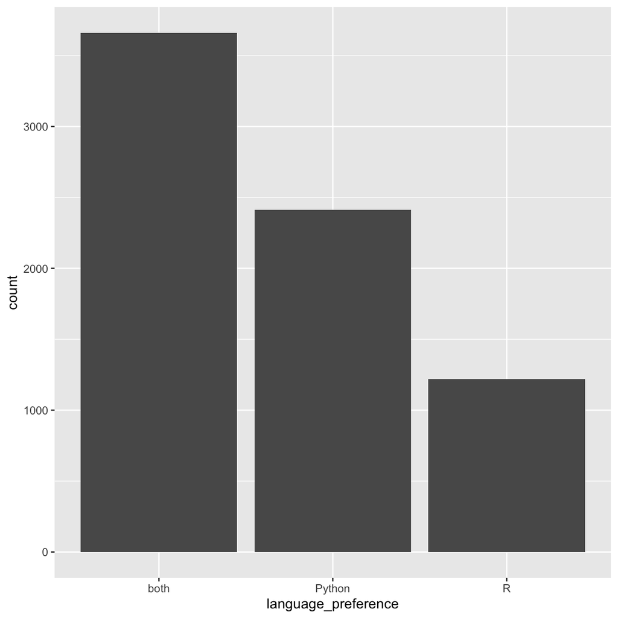

```r
# Create a bar chart
ggplot(debate_plot,aes(x=language_preference,y=count))+
    geom_bar(stat="identity") #if not specify identity then only have x
```

# Language recommendations

It looks like the largest group of professionals program in both Python and R. But what happens when they are asked which language they recommend to new learners? Do R lovers always recommend R?

```r
# Group by, summarise, arrange, mutate, and filter
recommendations <- debate_tools  %>%
    group_by(language_preference,LanguageRecommendationSelect)  %>%
    summarise(count = n()) %>%
    arrange(language_preference,desc(count)) %>%  #arrange within each group of language_preference
    mutate(row = row_number()) %>%
    filter(row<=4)
recommendations
```

```
## # A tibble: 16 x 4
## # Groups:   language_preference [4]
##    language_preference LanguageRecommendationSelect count   row
##    <chr>               <chr>                        <int> <int>
##  1 both                Python                        1917     1
##  2 both                R                              912     2
##  3 both                <NA>                           591     3
##  4 both                SQL                            108     4
##  5 neither             <NA>                          4447     1
##  6 neither             Python                        3088     2
##  7 neither             R                             1067     3
##  8 neither             C/C++/C#                       205     4
##  9 Python              Python                        1742     1
## 10 Python              <NA>                           459     2
## 11 Python              C/C++/C#                        48     3
## 12 Python              Matlab                          43     4
## 13 R                   R                              632     1
## 14 R                   <NA>                           221     2
## 15 R                   Python                         194     3
## 16 R                   SQL                             75     4
```

# The most recommended language by the language used

Finally, let’s graphically determine which languages are most recommended based on the language that a person uses.

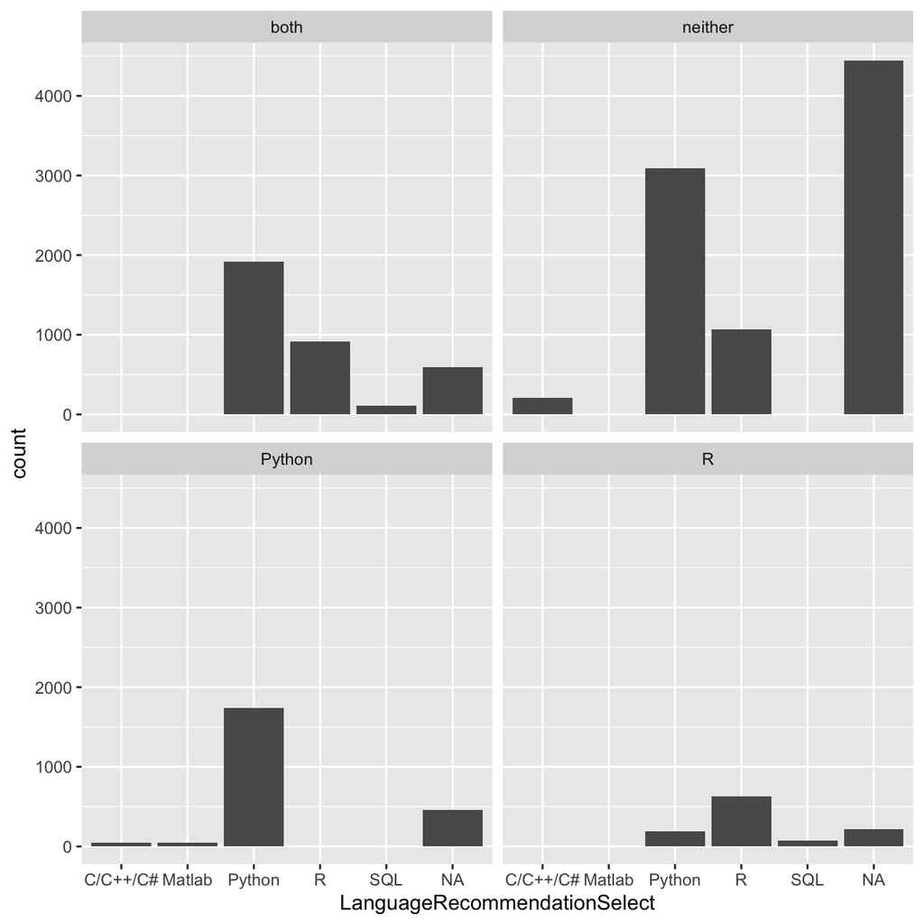

```r
# Create a faceted bar plot
ggplot(recommendations, aes(x=LanguageRecommendationSelect,y=count)) +
    geom_bar(stat="identity")+
    facet_wrap(~language_preference)
```

# Conclusion

We’ve found that Python is the most popular language used among Kaggle data scientists, but R users aren’t far behind!! While Python users may highly recommend that new learners learn Python, R users are loyal to R when making recommendations.